# 상점

## 라이선스

자료의 라이선스에 따라, 이 문서에는 특별히 [CC BY-SA 3.0](https://creativecommons.org/licenses/by-sa/3.0/) 라이선스가 적용됩니다.

## 자료

- [Kaggle](https://www.kaggle.com/)에 업로드된 [Supermarket store branches sales analysis](https://www.kaggle.com/datasets/surajjha101/stores-area-and-sales-data) CSV 데이터셋을 활용합니다.
  - 라이선스: [CC BY-SA 3.0](https://creativecommons.org/licenses/by-sa/3.0/)

```r
summary(stores)
```

```
##     Store.ID       Store_Area   Items_Available Daily_Customer_Count
##  Min.   :  1.0   Min.   : 775   Min.   : 932    Min.   :  10.0
##  1st Qu.:224.8   1st Qu.:1317   1st Qu.:1576    1st Qu.: 600.0
##  Median :448.5   Median :1477   Median :1774    Median : 780.0
##  Mean   :448.5   Mean   :1485   Mean   :1782    Mean   : 786.4
##  3rd Qu.:672.2   3rd Qu.:1654   3rd Qu.:1983    3rd Qu.: 970.0
##  Max.   :896.0   Max.   :2229   Max.   :2667    Max.   :1560.0
##   Store_Sales
##  Min.   : 14920
##  1st Qu.: 46530
##  Median : 58605
##  Mean   : 59351
##  3rd Qu.: 71872
##  Max.   :116320
```

- `Store.ID`: (Index) ID of the particular store.
- (면적) `Store_Area`: Physical Area of the store in yard square.
- (품목 개수) `Items_Available`: Number of different items available in the corresponding store.
- (일간 방문객 수) `Daily_Customer_Count`: Number of customers who visited to stores on an average over month.
- (월 매출) `Store_Sales`: Sales in (US $) that stores made.

## 계획

### 정보

`Store_Area`와 `Items_Available`, `Daily_Customer_Count`, `Store_Sales`의 관계를 확인합니다.

### 지혜

자료에 있는 상점의 면적이 그 상점의 품목 개수나 일간 방문객 수, 월 매출과 일정한 관계를 보이는지 확인합니다.

### 예상 효과

상점 창업 부지 면적을 합리적으로 결정할 수 있습니다.

## 실행

### 전처리

시각화 속도를 개선하기 위해 미리 `Store_Area`를 기준으로 오름차순 정렬합니다.

```r
stores <- stores[order(stores$Store_Area),]

write.csv(stores, "preprocessed.csv")
```

### 시각화

#### 상관관계

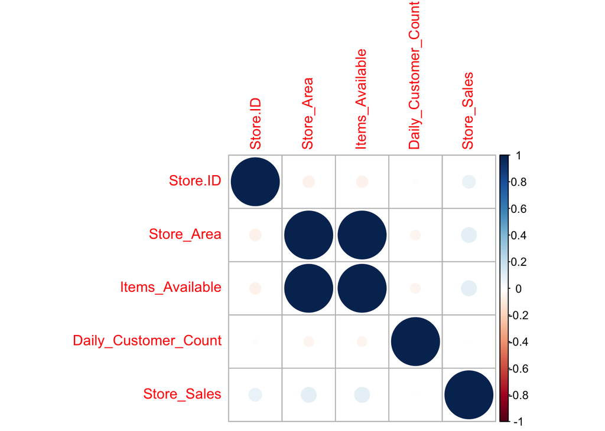

```r
corrplot(cor(stores))
```

#### 면적에 따른 품목 개수

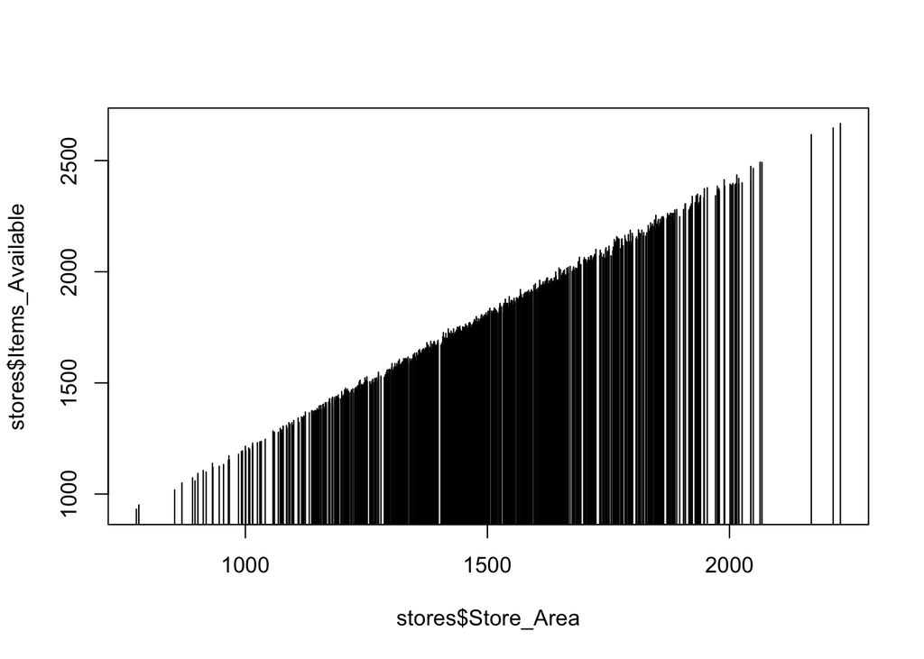

```r
plot(stores$Store_Area, stores$Items_Available, type="h")
```

#### 면적에 따른 일간 방문객 수

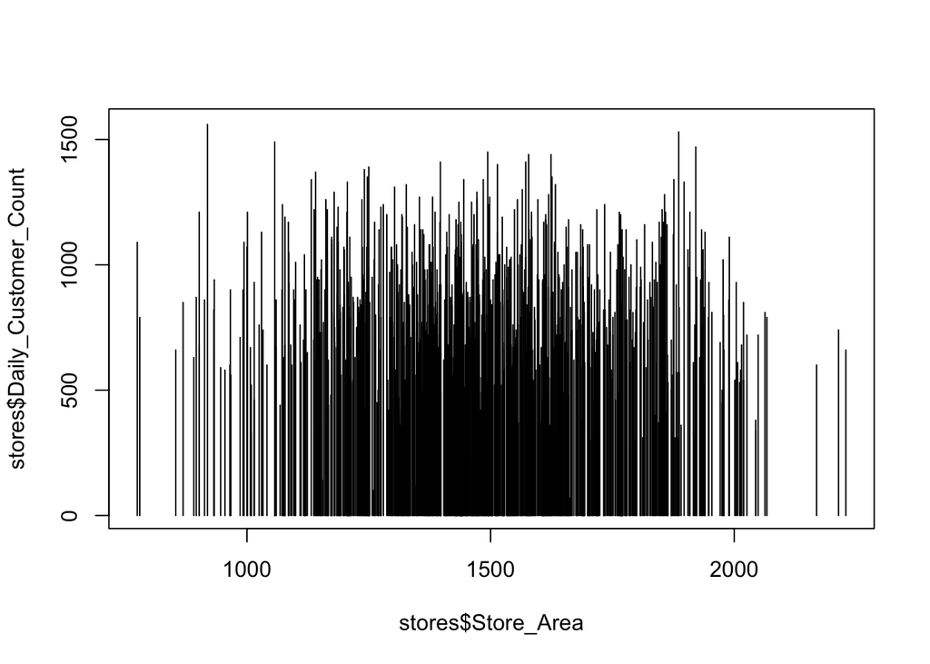

```r
plot(stores$Store_Area, stores$Daily_Customer_Count, type="h")
```

#### 면적에 따른 월 매출

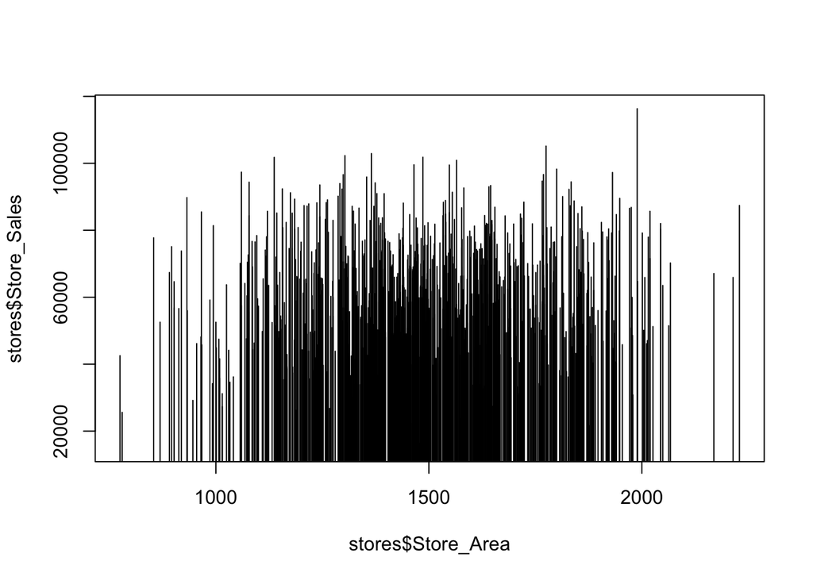

```r
plot(stores$Store_Area, stores$Store_Sales, type="h")
```

## 결과

### 설명

- 자료에 있는 상점의 면적과 품목 개수는 거의 정비례합니다.
- 하지만 면적(또는 품목 개수)과 일간 방문객 수는 상관관계가 거의 없습니다.
- 면적(또는 품목 개수)과 월 매출은 미묘한 상관관계가 있습니다.
  - 여전히 유의미하지 않지만 면적과 일간 방문객 수의 상관관계보다 높습니다.
- 덧붙이자면, 일간 방문객 수와 월 매출은 전혀 상관관계가 없습니다.

### 분석

- 상점이 넓으면 확실히 더 많은 상품을 판매할 수 있습니다.
- 하지만 의외로, 더 넓거나 판매 상품 개수가 더 많다고 고객이나 매출이 더 많지 않습니다.

### 개선 방안

- 상식적으로 중요하다고 판단되는 상점 부지 입지와의 상관관계를 분석할 수 있는 자료를 수집해야 합니다.